# Graphing Bootstrap Results

David Rodriguez

August 13, 2014

## Summary

In the following we explore visualizing the results from a bootstrap method. We will try to understand these results by plotting the densities and confidence intervals of our results by segmenting our data over categorical variables.

## Pseudo-Data

In our bootstrap method we assume data is generated over three categorical variables. These categorical variables are relationship, happiness, and weekday. The relationship variable can take on the values of Parent or Child. The happiness variable can be a range of the values 100, 150,…, and on up to 300. And lastly, the weekday variable has the values of January 1st to January 7th.

The code below generates the categorical variables,

```r
library(utils)
categories <- expand.grid(relationship = c("Parent","Child"),
                          happiness = seq(100, 300, 50),
                          weekday = seq(as.Date("2014-01-01"), as.Date("2014-01-07"), by="1 day")
                          )
```

The code below randomly generates our data and binds our previous categories with our data,

```r
sampled.data <- matrix(rexp(nrow(categories)*nrow(categories),
                            rate=.1),
                       ncol=nrow(categories))

p.data <- data.frame(categories, sampled.data)
p.data[1:5,1:5]
```

```
##   relationship happiness    weekday     X1     X2
## 1       Parent       100 2014-01-01 11.731  1.427
## 2        Child       100 2014-01-01 15.124  7.533
## 3       Parent       150 2014-01-01  3.920  5.343
## 4        Child       150 2014-01-01 18.943 10.051
## 5       Parent       200 2014-01-01  5.541  2.859
```

## Visualizing Densities

A major problem in visualizing large data sets is finding meaningful comparisons beyond testing for pair-wise correlations between variables. In the following we try to find alternatives.

```r
library(reshape2)
the.melt <- melt(p.data, id = c("relationship", "happiness","weekday"))
```

Now, we have our data and are ready to create our density plots. The following plots weekdays against happiness. The colorscheme indicates the portion of the density that is contributed by either the parent or child.

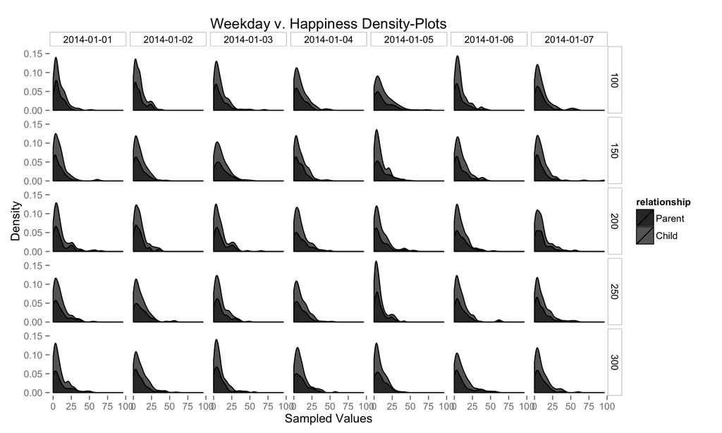

```r
library(ggplot2)
ggplot(the.melt, aes(x=value, y=..density..)) +
  geom_density(aes(fill=relationship), position="stack", alpha = 1) +
  facet_grid(happiness ~ weekday) +
  scale_fill_manual(values=c("#333333", "#666666")) +
  theme(strip.background = element_rect(colour="gray", fill="white"),
        panel.background = element_rect(fill = "white", colour = "white"),
        panel.grid.minor.x = element_line(colour = "white"),
        panel.grid.minor.y = element_line(colour = "white")) +
  labs(size= "Relationship",
       x = "Sampled Values",
       y = "Density",
       title = "Weekday v. Happiness Density-Plots")
```

## Conclusion

We have found a way to compare the proportions of three variables in a meaningful way. One interesting thing to note, is that the densities are ‘stacked’ which means the densities are comprised of two attributes: parent and child. Given the stacked densities, it is easy to compare the distributional shift from various combinations of the weekday and happiness variables.

## Visualizing Boxplots

It may be that our data and circumstances require us to plot our data with custom confidence intervals, that’s what we do now.

We first build a custom function to calculate the quantiles of a vector,

```r
new.conf.int <- function(x) {
  res <- quantile(x, probs = c(0.10, 0.30, 0.5, 0.70, 0.90))
  names(res) <- c("ymin", "lower", "middle", "upper", "ymax")
  res
}
```

For the purposes of this demo, I will try to get our boxplots as clear as possible. To do that, I suspect it’s a good idea to remove outliers (defined as a value greater than two standard deviations from the mean).

The following code removes outliers.

```r
tmp.melt <- the.melt[the.melt$value < sd(the.melt$value)*2 + mean(the.melt$value), ]
```

Now, we are ready to provide confidence intervals across weekdays against happiness. Further, our colorscheme indicates the group of parent or child observations.

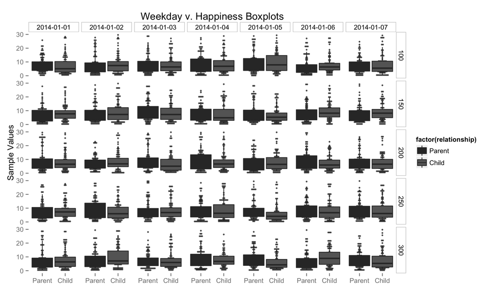

```r
ggplot(tmp.melt, aes(factor(relationship), value, fill = factor(relationship))) +
  geom_dotplot(aes(fill=value), binaxis = "y", binwidth = .9, stackdir="center", alpha = .6) +
  stat_summary(fun.data = new.conf.int , geom="boxplot", position="dodge", alpha = 1) +
  facet_grid(happiness ~ weekday) +
  scale_fill_manual(values=c("#333333", "#666666"))+
  theme(strip.background = element_rect(colour="gray", fill="white"),
        panel.background = element_rect(fill = "white", colour = "white"),
        panel.grid.minor.x = element_line(colour = "white"),
        panel.grid.minor.y = element_line(colour = "white")) +
  labs(size= "Relationship",
       x = "",
       y = "Sample Values",
       title = "Weekday v. Happiness Boxplots")
```

## Conclusion

We have found a way to compare the variance of three variables in a meaningful way. One interesting thing to note, is that the boxplots have custom quantiles. Further, we have displayed the observed values in a way which gives insight to any potential clustering in the quantiles.